# Descriptive statistics

Avireddy Rohan

9/30/2021

##reg.no :19BCE1180

```r
library(MASS)
library(dplyr)
```

QUESTIONS: Create a data frame ‘newsurvey’ that contains the survey data in MASS package after removing the NA values. Use it for answering following queries:

```r
data("survey")
survey_data=survey
str(survey_data)
```

```
## 'data.frame':    237 obs. of  12 variables:
##  $ Sex   : Factor w/ 2 levels "Female","Male": 1 2 2 2 2 1 2 1 2 2 ...
##  $ Wr.Hnd: num  18.5 19.5 18 18.8 20 18 17.7 17 20 18.5 ...
##  $ NW.Hnd: num  18 20.5 13.3 18.9 20 17.7 17.7 17.3 19.5 18.5 ...
##  $ W.Hnd : Factor w/ 2 levels "Left","Right": 2 1 2 2 2 2 2 2 2 2 ...
##  $ Fold  : Factor w/ 3 levels "L on R","Neither",..: 3 3 1 3 2 1 1 3 3 3 ...
##  $ Pulse : int  92 104 87 NA 35 64 83 74 72 90 ...
##  $ Clap  : Factor w/ 3 levels "Left","Neither",..: 1 1 2 2 3 3 3 3 3 3 ...
##  $ Exer  : Factor w/ 3 levels "Freq","None",..: 3 2 2 2 3 3 1 1 3 3 ...
##  $ Smoke : Factor w/ 4 levels "Heavy","Never",..: 2 4 3 2 2 2 2 2 2 2 ...
##  $ Height: num  173 178 NA 160 165 ...
##  $ M.I   : Factor w/ 2 levels "Imperial","Metric": 2 1 NA 2 2 1 1 2 2 2 ...
##  $ Age   : num  18.2 17.6 16.9 20.3 23.7 ...
```

```r
newsurvey <- na.omit(survey_data)
head(newsurvey)
```

```
##      Sex Wr.Hnd NW.Hnd W.Hnd    Fold Pulse  Clap Exer Smoke Height      M.I
## 1 Female   18.5   18.0 Right  R on L    92  Left Some Never 173.00   Metric
## 2   Male   19.5   20.5  Left  R on L   104  Left None Regul 177.80 Imperial
## 5   Male   20.0   20.0 Right Neither    35 Right Some Never 165.00   Metric
## 6 Female   18.0   17.7 Right  L on R    64 Right Some Never 172.72 Imperial
## 7   Male   17.7   17.7 Right  L on R    83 Right Freq Never 182.88 Imperial
## 8 Female   17.0   17.3 Right  R on L    74 Right Freq Never 157.00   Metric
##      Age
## 1 18.250
## 2 17.583
## 5 23.667
## 6 21.000
## 7 18.833
## 8 35.833
```

```r
any(is.na(newsurvey))
```

```
## [1] FALSE
```

1. How many the left and right handers are there?

```r
hand_freq=table(newsurvey$W.Hnd)
hand_freq
```

```
##
##  Left Right
##    12   156
```

2. Find the relative frequency distribution of left and right handers and display them with the precision of two decimal places.

```r
rel_hand_freq=hand_freq/nrow(newsurvey)
round(rel_hand_freq,2)
```

```
##
##  Left Right
##  0.07  0.93
```

3. Display the male left hander and female left hander in the column format.

```r
cond=newsurvey%>%
  group_by(Sex)%>%
  filter(W.Hnd=="Left")%>%
  dplyr::select(Sex,W.Hnd)
cond=data.frame(cond)
cond
```

```
##       Sex W.Hnd
## 1    Male  Left
## 2    Male  Left
## 3    Male  Left
## 4    Male  Left
## 5  Female  Left
## 6    Male  Left
## 7  Female  Left
## 8  Female  Left
## 9    Male  Left
## 10 Female  Left
## 11   Male  Left
## 12 Female  Left
```

4. What percentage of male right handers never smokes?

```r
no_smoke_male=newsurvey$Sex=="Male" & newsurvey$W.Hnd=="Right" & newsurvey$Smoke=="Never"
(nrow(newsurvey[no_smoke_male,])*100)/nrow(newsurvey)
```

```
## [1] 35.71429
```

5. Find the range of students’ height participated in the survey.

```r
range(newsurvey$Height)
```

```
## [1] 152 200
```

6. Break the height range into non-overlapping sub-intervals by defining a sequence of equal distance break points of 10 by rounding the range to nearest integer.

```r
minHeight=min(newsurvey$Height)
maxHeight=max(newsurvey$Height)
h_seq=seq(minHeight-2,maxHeight+2,by=10)
h_int=cut(newsurvey$Height,h_seq,right = FALSE)
h_int
```

```
##   [1] [170,180) [170,180) [160,170) [170,180) [180,190) [150,160) [170,180)
##   [8] [160,170) [150,160) [150,160) [150,160) [180,190) [170,180) [190,200)
##  [15] [180,190) [180,190) [180,190) [170,180) [170,180) [160,170) [180,190)
##  [22] [160,170) [180,190) [190,200) [180,190) [180,190) [150,160) [170,180)
##  [29] [180,190) [170,180) [160,170) [160,170) <NA>      [190,200) [170,180)
##  [36] [170,180) [180,190) [150,160) [170,180) [180,190) [160,170) [170,180)
##  [43] [160,170) [170,180) [170,180) [160,170) [160,170) [170,180) [160,170)
##  [50] [160,170) [170,180) [160,170) [160,170) [160,170) [170,180) [170,180)
##  [57] [180,190) [160,170) [170,180) [190,200) [160,170) [170,180) [170,180)
##  [64] [170,180) [160,170) [170,180) [180,190) [180,190) [170,180) [190,200)
##  [71] [170,180) [180,190) [160,170) [150,160) [150,160) [190,200) [170,180)
##  [78] [180,190) [170,180) [170,180) [180,190) [170,180) [170,180) [170,180)
##  [85] [150,160) [150,160) [180,190) [170,180) [160,170) [170,180) [180,190)
##  [92] [180,190) [160,170) [170,180) [170,180) [180,190) [170,180) [180,190)
##  [99] [180,190) [180,190) [160,170) [160,170) [190,200) [160,170) [150,160)
## [106] [170,180) [180,190) [170,180) [160,170) [180,190) [160,170) [190,200)
## [113] [160,170) [160,170) [170,180) [160,170) [180,190) [180,190) [160,170)
## [120] [150,160) [170,180) [170,180) [160,170) [160,170) [170,180) [160,170)
## [127] [160,170) [170,180) [170,180) [160,170) [160,170) [160,170) [170,180)
## [134] [190,200) [170,180) [180,190) [170,180) [160,170) [160,170) [170,180)
## [141] [150,160) [170,180) [160,170) [160,170) [170,180) [160,170) [170,180)
## [148] [160,170) [150,160) [160,170) [160,170) [160,170) [160,170) [160,170)
## [155] [160,170) [180,190) [180,190) [160,170) [160,170) [170,180) [180,190)
## [162] [160,170) [180,190) [160,170) [160,170) [160,170) [180,190) [160,170)
## Levels: [150,160) [160,170) [170,180) [180,190) [190,200)
```

7. Find the distribution of the height range according to the sub-intervals with cut with its right boundary opened. Display it in column form.

```r
p=data.frame(table(h_int))
p
```

```
##       h_int Freq
## 1 [150,160)   14
## 2 [160,170)   56
## 3 [170,180)   53
## 4 [180,190)   35
## 5 [190,200)    9
```

8. Which height range of students has mostly participated in the survey?

```r
p$h_int[which.max(p$Freq)]
```

```
## [1] [160,170)
## Levels: [150,160) [160,170) [170,180) [180,190) [190,200)
```

```r
mean(newsurvey$Height)
```

```
## [1] 172.4763
```

```r
median(newsurvey$Height)
```

```
## [1] 170.59
```

```r
sd(newsurvey$Height)
```

```
## [1] 9.959542
```

10. Which category of clap students has the maximum writing hand span?

```r
ss=newsurvey%>%
  group_by(Clap)%>%
  filter(Wr.Hnd==max(Wr.Hnd))%>%
  dplyr::select(Clap,Wr.Hnd)
arrange(ss,Wr.Hnd,desc=TRUE)
```

```
## # A tibble: 3 x 2
## # Groups:   Clap [3]
##   Clap    Wr.Hnd
##   <fct>    <dbl>
## 1 Neither   22.8
## 2 Left      23.2
## 3 Right     23.2
```

```r
ss%>%
  filter(Wr.Hnd==max(Wr.Hnd))%>%
  dplyr::select(Clap)
```

```
## # A tibble: 3 x 1
## # Groups:   Clap [3]
##   Clap
##   <fct>
## 1 Left
## 2 Neither
## 3 Right
```

11. Compute the covariance and correlation between height and writing span.

```r
cov(newsurvey$Height,newsurvey$Wr.Hnd)
```

```
## [1] 12.44408
```

```r
cor(newsurvey$Height,newsurvey$Wr.Hnd)
```

```
## [1] 0.6510316
```

12. Display the 30%, 60% and 80% percentile of the height data.

```r
quantile(newsurvey$Height,c(.3,.6,.8))
```

```
##    30%    60%    80%
## 167.00 175.00 180.34
```

Frame any three questions on descriptive statistics to analyse the categorical & quantitative variables present in the data of your choice.

1.display the interquartile range and boxplot for Height of students

```r
IQR(newsurvey$Height)
```

```
## [1] 15
```

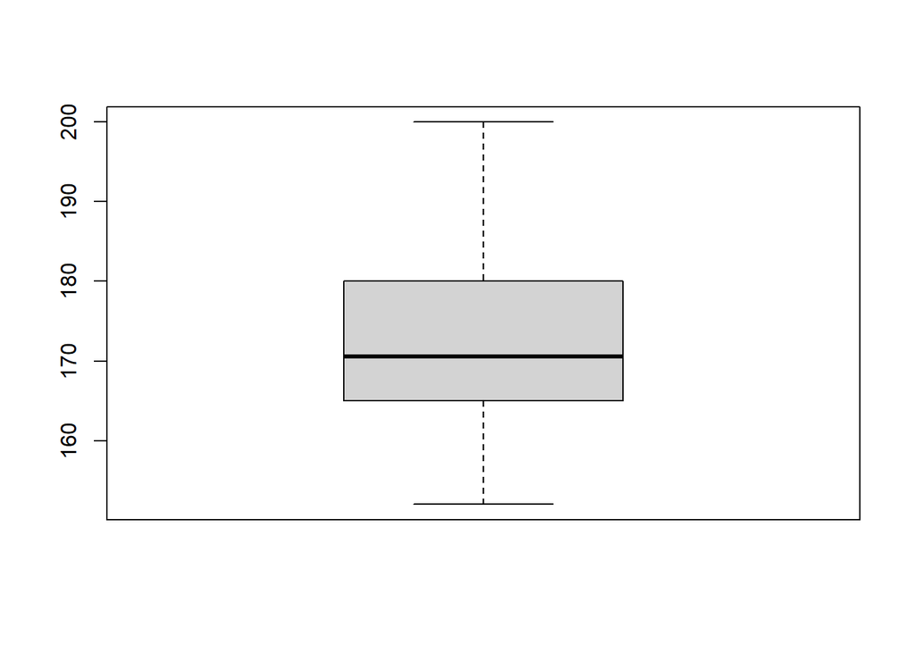

```r
boxplot(newsurvey$Height)
```

2.display various descriptive metrics with respect to the writing hand of student

```r
by(newsurvey,newsurvey$Wr.Hnd,summary)
```

```
## newsurvey$Wr.Hnd: 13
##      Sex        Wr.Hnd       NW.Hnd       W.Hnd        Fold       Pulse
##  Female:1   Min.   :13   Min.   :12.5   Left :0   L on R :1   Min.   :80
##  Male  :0   1st Qu.:13   1st Qu.:12.5   Right:1   Neither:0   1st Qu.:80
##             Median :13   Median :12.5             R on L :0   Median :80
##             Mean   :13   Mean   :12.5                         Mean   :80
##             3rd Qu.:13   3rd Qu.:12.5                         3rd Qu.:80
##             Max.   :13   Max.   :12.5                         Max.   :80
##       Clap     Exer     Smoke       Height          M.I         Age
##  Left   :0   Freq:1   Heavy:0   Min.   :165   Imperial:0   Min.   :18.17
##  Neither:0   None:0   Never:1   1st Qu.:165   Metric  :1   1st Qu.:18.17
##  Right  :1   Some:0   Occas:0   Median :165                Median :18.17
##                       Regul:0   Mean   :165                Mean   :18.17
##                                 3rd Qu.:165                3rd Qu.:18.17
##                                 Max.   :165                Max.   :18.17
## ------------------------------------------------------------
## newsurvey$Wr.Hnd: 14
##      Sex        Wr.Hnd       NW.Hnd       W.Hnd        Fold       Pulse
##  Female:1   Min.   :14   Min.   :13.5   Left :0   L on R :0   Min.   :87
##  Male  :0   1st Qu.:14   1st Qu.:13.5   Right:1   Neither:0   1st Qu.:87
##             Median :14   Median :13.5             R on L :1   Median :87
##             Mean   :14   Mean   :13.5                         Mean   :87
##             3rd Qu.:14   3rd Qu.:13.5                         3rd Qu.:87
##             Max.   :14   Max.   :13.5                         Max.   :87
##       Clap     Exer     Smoke       Height            M.I         Age
##  Left   :0   Freq:1   Heavy:0   Min.   :165.1   Imperial:1   Min.   :17.08
##  Neither:1   None:0   Never:0   1st Qu.:165.1   Metric  :0   1st Qu.:17.08
##  Right  :0   Some:0   Occas:1   Median :165.1                Median :17.08
##                       Regul:0   Mean   :165.1                Mean   :17.08
##                                 3rd Qu.:165.1                3rd Qu.:17.08
##                                 Max.   :165.1                Max.   :17.08
## ------------------------------------------------------------
## newsurvey$Wr.Hnd: 15
##      Sex        Wr.Hnd       NW.Hnd     W.Hnd        Fold       Pulse
##  Female:1   Min.   :15   Min.   :13   Left :0   L on R :0   Min.   :80
##  Male  :0   1st Qu.:15   1st Qu.:13   Right:1   Neither:0   1st Qu.:80
##             Median :15   Median :13             R on L :1   Median :80
##             Mean   :15   Mean   :13                         Mean   :80
##             3rd Qu.:15   3rd Qu.:13                         3rd Qu.:80
##             Max.   :15   Max.   :13                         Max.   :80
```

[output cut: 908 more lines]

```
##             Max.   :23.2   Max.   :23.20
##      Pulse            Clap     Exer     Smoke       Height          M.I
##  Min.   :75.00   Left   :1   Freq:2   Heavy:0   Min.   :180   Imperial:0
##  1st Qu.:77.25   Neither:0   None:0   Never:1   1st Qu.:182   Metric  :2
##  Median :79.50   Right  :1   Some:0   Occas:0   Median :184
##  Mean   :79.50                        Regul:1   Mean   :184
##  3rd Qu.:81.75                                  3rd Qu.:186
##  Max.   :84.00                                  Max.   :188
##       Age
##  Min.   :18.92
##  1st Qu.:18.92
##  Median :18.92
##  Mean   :18.92
##  3rd Qu.:18.92
##  Max.   :18.92
```

3.DISPLAY the number of smokers in each age group.

```r
range(newsurvey$Age)
```

```
## [1] 16.917 70.417
```

```r
age_seq=seq(min(newsurvey$Age),max(newsurvey$Age),10)
age_int=cut(newsurvey$Age,age_seq,right=FALSE)
cbind(newsurvey,age_int)
```

```
##        Sex Wr.Hnd NW.Hnd W.Hnd    Fold Pulse    Clap Exer Smoke Height      M.I
## 1   Female   18.5   18.0 Right  R on L    92    Left Some Never 173.00   Metric
## 2     Male   19.5   20.5  Left  R on L   104    Left None Regul 177.80 Imperial
## 5     Male   20.0   20.0 Right Neither    35   Right Some Never 165.00   Metric
## 6   Female   18.0   17.7 Right  L on R    64   Right Some Never 172.72 Imperial
## 7     Male   17.7   17.7 Right  L on R    83   Right Freq Never 182.88 Imperial
## 8   Female   17.0   17.3 Right  R on L    74   Right Freq Never 157.00   Metric
## 9     Male   20.0   19.5 Right  R on L    72   Right Some Never 175.00   Metric
## 10    Male   18.5   18.5 Right  R on L    90   Right Some Never 167.00   Metric
## 11  Female   17.0   17.2 Right  L on R    80   Right Freq Never 156.20 Imperial
## 14  Female   19.5   20.2 Right  L on R    66 Neither Some Never 155.00   Metric
## 17  Female   18.0   18.0 Right  L on R    89 Neither Freq Never 157.00   Metric
## 18    Male   19.4   19.2  Left  R on L    74   Right Some Never 182.88 Imperial
## 20    Male   21.0   20.9 Right  R on L    78   Right Freq Never 177.00   Metric
## 21    Male   21.5   22.0 Right  R on L    72    Left Freq Never 190.50 Imperial
```

[output cut: 323 more lines]

```r
newsurvey["age_int"]=age_int
k=newsurvey%>%
  group_by(age_int)%>%
  dplyr::select(age_int,Smoke)
table(k)
```

```
##              Smoke
## age_int       Heavy Never Occas Regul
##   [16.9,26.9)     6   125    12    12
##   [26.9,36.9)     0     6     1     2
##   [36.9,46.9)     1     2     0     0
##   [46.9,56.9)     0     0     0     0
##   [56.9,66.9)     0     0     0     0
```